# I Dati Siamo Noi: Introduzione a R

Niccolò Cibei, Julia Maria Wdowinska

# Introduzione

In questa lezione, copriremo alcuni concetti di base di R e dimostreremo come eseguire l’analisi dei dati utilizzando R.

R è un potente linguaggio di programmazione e ambiente software comunemente utilizzato per il calcolo statistico e l’analisi dei dati. Può essere scaricato e installato dal [sito web Comprehensive R Archive Network (CRAN)](https://cran.r-project.org/). Una volta installato, è possibile avviare RStudio, che fornisce un’interfaccia utente intuitiva per lavorare con R.

Per scaricare RStudio, è necessario visitare il [sito web di RStudio](https://www.rstudio.com/products/rstudio/download/) e selezionare la versione appropriata per il proprio sistema operativo.

Se l’installazione di R e RStudio non è possibile per qualsiasi motivo, Posit Cloud offre un’alternativa conveniente.

## Utilizzo di Rstudio su Posit Cloud

Posit Cloud è una piattaforma che permette di eseguire analisi dati direttamente dal browser web, senza la necessità di installare alcun software aggiuntivo.

Per utilizzare Posit Cloud, è necessario creare un account sul [sito web ufficiale](https://posit.cloud/).

Per avviare RStudio su Posit Cloud, è necessario creare un nuovo progetto selezionando *New Project* e quindi *New RStudio Project*. Successivamente, è possibile creare un nuovo file R cliccando su *File* -> *New File* -> *R Script*. Una volta creato il progetto, sarà possibile accedervi da qualsiasi dispositivo utilizzando le credenziali dell’account Posit Cloud.

# Concetti di Base di R

## R come Calcolatrice

R può essere utilizzato come una semplice calcolatrice per eseguire operazioni aritmetiche.

```r
# Somma
2 + 3
```

```
## [1] 5
```

```r
# Differenza
5 - 3
```

```
## [1] 2
```

```r
# Prodotto
2 * 3
```

```
## [1] 6
```

```r
# Divisione
6 / 2
```

```
## [1] 3
```

```r
# Esponenziale
2 ^ 3
```

```
## [1] 8
```

```r
# Modulo (il resto della divisione euclidea del primo numero per il secondo)
10 %% 3
```

```
## [1] 1
```

```r
# Radice quadrata
sqrt(9)
```

```
## [1] 3
```

```r
# Valore assoluto
abs(-10)
```

```
## [1] 10
```

```r
# Espressioni più complesse
sqrt(((3 * 2) ^ 4) * 0.1)^5
```

```
## [1] 191210.8
```

```r
# Operatori relazionali: minore di
2 < 3
```

```
## [1] TRUE
```

```r
# Operatori relazionali: maggiore o uguale a
2 >= 3
```

```
## [1] FALSE
```

```r
# Operatori relazionali: uguale a
2 == 3 # Nota il doppio segno uguale "=="
```

```
## [1] FALSE
```

```r
# Operatori relazionali: diverso da
2 != 3
```

```
## [1] TRUE
```

## Oggetti e Tipi di Dati

In R, gli oggetti possono essere pensati come variabili in cui memorizzare dati e risultati di calcoli. Possono rappresentare numeri, stringhe di testo, valori logici o anche strutture di dati più complesse. Una volta assegnati a un oggetto, i valori possono essere recuperati e manipolati in base alle necessità dell’analisi dei dati.

```r
# Variabile numerica
age <- 25

class(age)
```

```
## [1] "numeric"
```

```r
age
```

```
## [1] 25
```

```r
# Variabile di testo (stringa)
name <- "Alice"

class(name)
```

```
## [1] "character"
```

```r
name
```

```
## [1] "Alice"
```

```r
# Variabile logica
is_student <- TRUE

class(is_student)
```

```
## [1] "logical"
```

```r
is_student
```

```
## [1] TRUE
```

```r
# Vettore
numbers <- c(1, 2, 3, 4, 5)

class(numbers)
```

```
## [1] "numeric"
```

```r
numbers
```

```
## [1] 1 2 3 4 5
```

```r
# Matrice
mat <- matrix(1:9, nrow = 3)

class(mat)
```

```
## [1] "matrix" "array"
```

```r
mat
```

```
##      [,1] [,2] [,3]
## [1,]    1    4    7
## [2,]    2    5    8
## [3,]    3    6    9
```

```r
# Data frame (struttura dati tabellare)
df <- data.frame(
  name = c("Alice", "Bob", "Charlie"),
  age = c(25, 30, 35),
  city = c("Rome", "Paris", "Berlin")
)

class(df)
```

```
## [1] "data.frame"
```

```r
df
```

```
##      name age   city
## 1   Alice  25   Rome
## 2     Bob  30  Paris
## 3 Charlie  35 Berlin
```

## Alcune Operazioni su Oggetti

Le operazioni sugli oggetti in R consentono di manipolare i valori memorizzati nelle variabili. Questo può includere operazioni aritmetiche, come l’aggiunta o la sottrazione di numeri, e l’accesso agli elementi dei vettori e delle matrici per eseguire operazioni più complesse sui dati.

```r
# Operazioni con le variabili
a <- 5
b <- 3

sum <- a + b
sum
```

```
## [1] 8
```

```r
# Cambiare il tipo di variabile
x <- "123"

# Convertire in numerico
x_numeric <- as.numeric(x)

class(x_numeric)
```

```
## [1] "numeric"
```

```r
x_numeric
```

```
## [1] 123
```

```r
# Convertire in carattere
x_character <- as.character(x_numeric)

class(x_character)
```

```
## [1] "character"
```

```r
x_character
```

```
## [1] "123"
```

```r
# Accesso agli elementi di un vettore
numbers
```

```
## [1] 1 2 3 4 5
```

```r
# Accedere al primo elemento
numbers[1]
```

```
## [1] 1
```

```r
# Accedere al terzo elemento
numbers[3]
```

```
## [1] 3
```

```r
# Accesso agli elementi di una matrice
mat
```

```
##      [,1] [,2] [,3]
## [1,]    1    4    7
## [2,]    2    5    8
## [3,]    3    6    9
```

```r
# Accedere all'elemento nella seconda riga e terza colonna
mat[2, 3]
```

```
## [1] 8
```

```r
# Accedere alla prima riga
mat[1, ]
```

```
## [1] 1 4 7
```

```r
# Accedere alla terza colonna
mat[, 3]
```

```
## [1] 7 8 9
```

```r
# Accesso agli elementi di un data frame
df
```

```
##      name age   city
## 1   Alice  25   Rome
## 2     Bob  30  Paris
## 3 Charlie  35 Berlin
```

```r
# Accedere alla colonna 'name'
df$name
```

```
## [1] "Alice"   "Bob"     "Charlie"
```

```r
# Accedere alla seconda riga
df[2, ]
```

```
##   name age  city
## 2  Bob  30 Paris
```

```r
# Accedere all'elemento nella seconda riga e seconda colonna
df[2, 2]
```

```
## [1] 30
```

```r
# Accesso condizionale: Selezionare le righe con età maggiore di 25
df[df$age > 25, ]
```

```
##      name age   city
## 2     Bob  30  Paris
## 3 Charlie  35 Berlin
```

# Introduzione alla Manipolazione dei Dati con `dplyr`

`dplyr` è un pacchetto di R progettato per semplificare e velocizzare il processo di manipolazione dei dati. Fornisce un insieme coerente di funzioni per selezionare, filtrare, trasformare e aggregare i dati.

```r
# Caricamento del pacchetto 'dplyr'
#install.packages("dplyr")
library(dplyr)
```

```r
# Filtra le righe con età maggiore di 25
df_filtered <- filter(df, age > 25)
df_filtered
```

```
##      name age   city
## 1     Bob  30  Paris
## 2 Charlie  35 Berlin
```

```r
# Seleziona solo le colonne 'name' e 'city'
df_selected <- select(df, name, city)
df_selected
```

```
##      name   city
## 1   Alice   Rome
## 2     Bob  Paris
## 3 Charlie Berlin
```

```r
# Crea una nuova colonna 'age_squared'
df_mutated <- mutate(df, age_squared = age^2)
df_mutated
```

```
##      name age   city age_squared
## 1   Alice  25   Rome         625
## 2     Bob  30  Paris         900
## 3 Charlie  35 Berlin        1225
```

```r
# Ordina le righe in base all'età in ordine crescente
df_ordered <- arrange(df, age)
df_ordered
```

```
##      name age   city
## 1   Alice  25   Rome
## 2     Bob  30  Paris
## 3 Charlie  35 Berlin
```

```r
# Ordina le righe in base all'età in ordine decrescente
df_ordered_desc <- arrange(df, desc(age))
df_ordered_desc
```

```
##      name age   city
## 1 Charlie  35 Berlin
## 2     Bob  30  Paris
## 3   Alice  25   Rome
```

## Esempio di Utilizzo di `dplyr` con il Pipe Operator

```r
# Filtra le righe con età maggiore di 25 e seleziona solo le colonne 'name' e 'city'
df_manipulated <- df %>%
  filter(age > 25) %>%
  select(name, city)

df_manipulated
```

```
##      name   city
## 1     Bob  Paris
## 2 Charlie Berlin
```

# Caricamento ed Esplorazione dei Dati

## Introduzione ai Dataset

Lavoreremo con un dataset di esempio per dimostrare le tecniche di analisi dei dati in R. Iniziamo caricando il dataset in R.

```r
# Impostazione della directory di lavoro
#setwd("D:/Studies/Materials/Coding-Girls")

# Caricamento del dataset
data <- readRDS("spotify.rds")
```

```r
# Controllo delle dimensioni del dataset
dim(data)
```

```
## [1] 130663     17
```

Questo dataset contiene 130.663 brani musicali di Spotify, presi da [qui](https://www.kaggle.com/datasets/tomigelo/spotify-audio-features).

Include le seguenti variabili:

- `artist_name`: il nome dell’artista,
- `track_id`: l’ID della canzone,
- `track_name`: il nome della canzone,
- `acousticness`, `danceability`, `energy`, `instrumentalness`, `liveness`, `loudness`, `speechiness`, `valence`: un insieme di caratteristiche della canzone,
- `duration_ms`: durata della canzone (in millisecondi),
- `key`: la “chiave” della canzone,
- `mode`: un valore che indica se la canzone è in scala minore (0) o maggiore (1),
- `tempo`: il BPM (beats per minute) della canzone,
- `time_signature`: la firma temporale,
- `popularity`: una misura della “popolarità” della canzone, in base al numero di riproduzioni (varia da 0 a 100).

```r
# Visualizzazione delle prime righe del dataset
head(data)
```

```
##   artist_name               track_id
## 1          YG 2RM4jf1Xa9zPgMGRDiht8O
## 2          YG 1tHDG53xJNGsItRA3vfVgs
## 3       R3HAB 6Wosx2euFPMT14UXiWudMy
## 4  Chris Cooq 3J2Jpw61sO7l6Hc7qdYV91
## 5  Chris Cooq 2jbYvQCyPgX3CdmAzeVeuS
## 6       Curbo 26Y1lX7ZOpw9Ql3gGAlqLK
##                                       track_name acousticness danceability
## 1 Big Bank feat. 2 Chainz, Big Sean, Nicki Minaj     5.82e-03        0.743
## 2                   BAND DRUM (feat. A$AP Rocky)     2.44e-02        0.846
## 3                                  Radio Silence     2.50e-02        0.603
## 4                                        Lactose     2.94e-02        0.800
## 5                            Same - Original mix     3.52e-05        0.783
## 6                      Debauchery - Original mix     1.15e-03        0.810
##   duration_ms energy instrumentalness key liveness loudness mode speechiness
## 1      238373  0.339            0.000   1   0.0812   -7.678    1      0.4090
## 2      214800  0.557            0.000   8   0.2860   -7.259    1      0.4570
## 3      138913  0.723            0.000   9   0.0824   -5.890    0      0.0454
## 4      125381  0.579            0.912   5   0.0994  -12.118    0      0.0701
## 5      124016  0.792            0.878   7   0.0332  -10.277    1      0.0661
## 6      124016  0.417            0.919   9   0.1060  -10.783    0      0.0793
##     tempo time_signature valence popularity
## 1 203.927              4   0.118         15
## 2 159.009              4   0.371          0
## 3 114.966              4   0.382         56
## 4 123.003              4   0.641          0
## 5 120.047              4   0.928          0
## 6 120.025              4   0.837          0
```

```r
# Controllo per i valori mancanti
colSums(is.na(data))
```

```
##      artist_name         track_id       track_name     acousticness
##                0                0                0                0
##     danceability      duration_ms           energy instrumentalness
##                0                0                0                0
##              key         liveness         loudness             mode
##                0                0                0                0
##      speechiness            tempo   time_signature          valence
##                0                0                0                0
##       popularity
##                0
```

Non ci sono valori mancanti.

## Analisi Esplorativa dei Dati (EDA)

L’EDA consiste nell’esaminare e riassumere le principali caratteristiche di un dataset. Utilizzeremo varie funzioni di R per esplorare il dataset.

```r
# Informazioni sulla struttura del dataset
str(data)
```

```
## 'data.frame':    130663 obs. of  17 variables:
##  $ artist_name     : chr  "YG" "YG" "R3HAB" "Chris Cooq" ...
##  $ track_id        : chr  "2RM4jf1Xa9zPgMGRDiht8O" "1tHDG53xJNGsItRA3vfVgs" "6Wosx2euFPMT14UXiWudMy" "3J2Jpw61sO7l6Hc7qdYV91" ...
##  $ track_name      : chr  "Big Bank feat. 2 Chainz, Big Sean, Nicki Minaj" "BAND DRUM (feat. A$AP Rocky)" "Radio Silence" "Lactose" ...
##  $ acousticness    : num  5.82e-03 2.44e-02 2.50e-02 2.94e-02 3.52e-05 1.15e-03 5.39e-04 1.15e-01 5.84e-05 8.11e-05 ...
##  $ danceability    : num  0.743 0.846 0.603 0.8 0.783 0.81 0.819 0.885 0.74 0.813 ...
##  $ duration_ms     : int  238373 214800 138913 125381 124016 124016 132742 181838 124016 132742 ...
##  $ energy          : num  0.339 0.557 0.723 0.579 0.792 0.417 0.72 0.348 0.472 0.731 ...
##  $ instrumentalness: num  0 0 0 0.912 0.878 0.919 0.863 0 0.847 0.91 ...
##  $ key             : int  1 8 9 5 7 9 4 9 8 11 ...
##  $ liveness        : num  0.0812 0.286 0.0824 0.0994 0.0332 0.106 0.0727 0.107 0.0959 0.0727 ...
##  $ loudness        : num  -7.68 -7.26 -5.89 -12.12 -10.28 ...
##  $ mode            : int  1 1 0 0 1 0 0 1 1 1 ...
##  $ speechiness     : num  0.409 0.457 0.0454 0.0701 0.0661 0.0793 0.151 0.451 0.0551 0.0697 ...
##  $ tempo           : num  204 159 115 123 120 ...
##  $ time_signature  : int  4 4 4 4 4 4 4 4 4 4 ...
##  $ valence         : num  0.118 0.371 0.382 0.641 0.928 0.837 0.934 0.18 0.622 0.944 ...
##  $ popularity      : int  15 0 56 0 0 0 0 0 0 0 ...
```

```r
# Statistiche di riepilogo
summary(data)
```

```
##  artist_name          track_id          track_name         acousticness
##  Length:130663      Length:130663      Length:130663      Min.   :0.0000
##  Class :character   Class :character   Class :character   1st Qu.:0.0316
##  Mode  :character   Mode  :character   Mode  :character   Median :0.2030
##                                                           Mean   :0.3425
##                                                           3rd Qu.:0.6360
##                                                           Max.   :0.9960
##   danceability     duration_ms          energy       instrumentalness
##  Min.   :0.0000   Min.   :   3203   Min.   :0.0000   Min.   :0.000000
##  1st Qu.:0.4590   1st Qu.: 163922   1st Qu.:0.3960   1st Qu.:0.000000
##  Median :0.6050   Median : 201901   Median :0.6030   Median :0.000149
##  Mean   :0.5815   Mean   : 212633   Mean   :0.5692   Mean   :0.224018
##  3rd Qu.:0.7270   3rd Qu.: 241048   3rd Qu.:0.7750   3rd Qu.:0.440000
##  Max.   :0.9960   Max.   :5610020   Max.   :1.0000   Max.   :1.000000
##       key            liveness         loudness            mode
##  Min.   : 0.000   Min.   :0.0000   Min.   :-60.000   Min.   :0.0000
##  1st Qu.: 2.000   1st Qu.:0.0975   1st Qu.:-11.898   1st Qu.:0.0000
##  Median : 5.000   Median :0.1240   Median : -7.979   Median :1.0000
##  Mean   : 5.232   Mean   :0.1949   Mean   : -9.974   Mean   :0.6077
##  3rd Qu.: 8.000   3rd Qu.:0.2360   3rd Qu.: -5.684   3rd Qu.:1.0000
##  Max.   :11.000   Max.   :0.9990   Max.   :  1.806   Max.   :1.0000
##   speechiness         tempo        time_signature     valence
##  Min.   :0.0000   Min.   :  0.00   Min.   :0.000   Min.   :0.0000
##  1st Qu.:0.0389   1st Qu.: 96.01   1st Qu.:4.000   1st Qu.:0.2240
##  Median :0.0559   Median :120.03   Median :4.000   Median :0.4200
##  Mean   :0.1120   Mean   :119.47   Mean   :3.879   Mean   :0.4396
##  3rd Qu.:0.1290   3rd Qu.:139.64   3rd Qu.:4.000   3rd Qu.:0.6380
##  Max.   :0.9660   Max.   :249.98   Max.   :5.000   Max.   :1.0000
##    popularity
##  Min.   :  0.00
##  1st Qu.:  7.00
##  Median : 22.00
##  Mean   : 24.21
##  3rd Qu.: 38.00
##  Max.   :100.00
```

## Visualizzazione dei Dati con `ggplot2`

In questa sezione, esploreremo la visualizzazione dei dati utilizzando il pacchetto `ggplot2` in R. Mentre R offre strumenti di visualizzazione dei dati utili nella sua libreria base, `ggplot2` offre un approccio più flessibile e potente alla creazione di grafici.

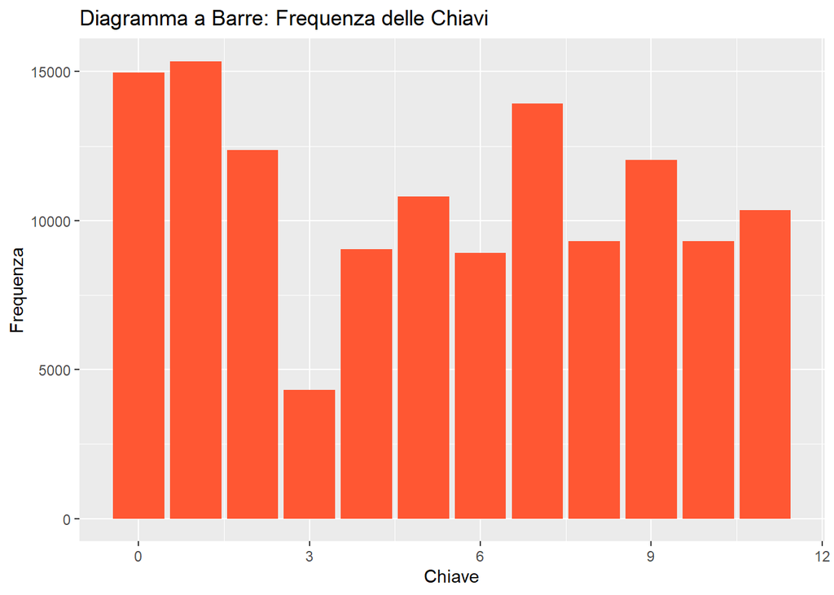

```r
# Caricamento del pacchetto 'ggplot2'
#install.packages("ggplot2")
library(ggplot2)

# Diagramma a barre
ggplot(data, aes(x = key)) +
  geom_bar(fill = "#FF5733") +
  labs(x = "Chiave", y = "Frequenza", title = "Diagramma a Barre: Frequenza delle Chiavi")
```

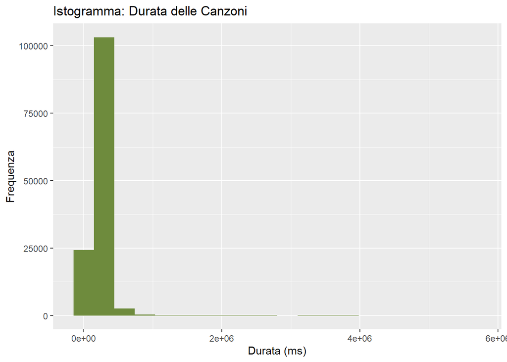

```r
# Istogramma
ggplot(data, aes(x = duration_ms)) +
  geom_histogram(fill = "#6E8B3D", bins = 20) +
  labs(x = "Durata (ms)", y = "Frequenza", title = "Istogramma: Durata delle Canzoni")
```

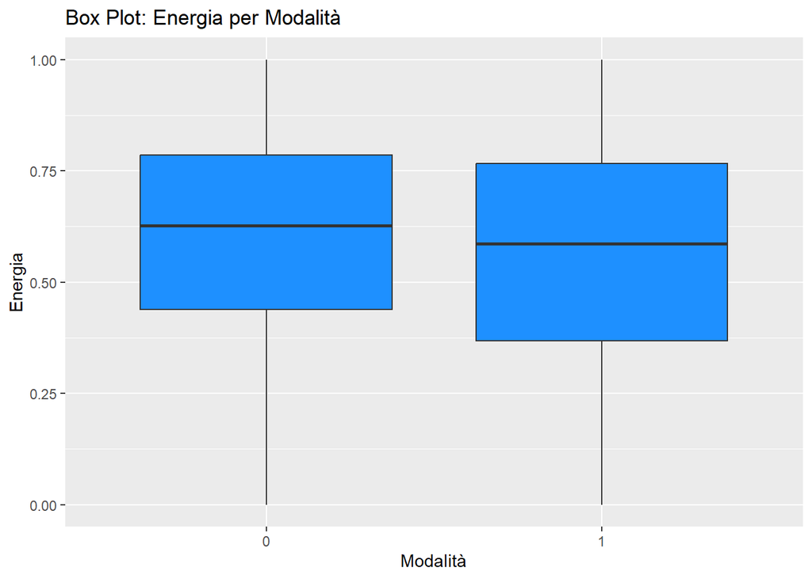

```r
# Box plot
ggplot(data, aes(x = factor(mode), y = energy)) +
  geom_boxplot(fill = "#1E90FF") +
  labs(x = "Modalità", y = "Energia", title = "Box Plot: Energia per Modalità")
```

Per visualizzare la relazione tra due variabili continue, puoi utilizzare un diagramma di dispersione (scatter plot).

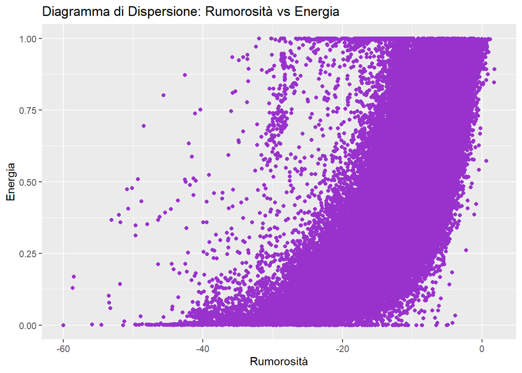

```r
# Scatter plot
ggplot(data, aes(x = loudness, y = energy)) +
  geom_point(color = "#9932CC") +
  labs(x = "Rumorosità", y = "Energia", title = "Diagramma di Dispersione: Rumorosità vs Energia")
```

## Statistiche Descrittive

Nella lezione precedente abbiamo esaminato diverse misure statistiche utilizzate per esplorare e analizzare i dati. Ora mostreremo come queste misure possono essere calcolate utilizzando R.

```r
# Mediana
median(data$duration_ms)
```

```
## [1] 201901
```

```r
# Moda
mode_result <- table(data$key)
names(mode_result)[which.max(mode_result)]
```

```
## [1] "1"
```

```r
# Campo di Variazione (Range)
range(data$duration_ms)
```

```
## [1]    3203 5610020
```

```r
# Quartili (Q1 e Q3)
quantile(data$duration_ms, probs = c(0.25, 0.75))
```

```
##      25%      75%
## 163922.5 241047.5
```

```r
# Scarto Interquartile (Interquartile Range)
IQR(data$duration_ms)
```

```
## [1] 77125
```

```r
# Deviazione Standard
sd(data$duration_ms)
```

```
## [1] 123155.1
```

```r
# Varianza
var(data$duration_ms)
```

```
## [1] 15167169998
```

```r
# Correlazione di Pearson tra 'duration_ms' e 'energy'
cor(data$duration_ms, data$energy, method = "pearson")
```

```
## [1] -0.01988486
```

```r
# Correlazione di Spearman tra 'instrumentalness' e 'key'
cor(data$instrumentalness, data$key, method = "spearman")
```

```
## [1] -0.02167953
```

# Esempio di Analisi Interessante

Guarda le caratteristiche delle canzoni di 3 artisti che ti piaccono. Come si collocano i tuoi artisti preferiti rispetto al resto del campione (ad esempio, sono più o meno rumorosi, etc.)?

```r
# Artisti preferiti
artists <- c("Kygo", "Little Mix", "Johann Sebastian Bach")
artists
```

```
## [1] "Kygo"                  "Little Mix"            "Johann Sebastian Bach"
```

```r
# Ricodifica i nomi degli artisti
data.1 <- data %>%
  mutate_at("artist_name", function(x) ifelse(x %in% artists, x, "Other"))

data.1 %>%
  select(artist_name) %>%
  distinct() # Per vedere i nomi degli artisti unici dopo la ricodifica
```

```
##             artist_name
## 1                 Other
## 2                  Kygo
## 3            Little Mix
## 4 Johann Sebastian Bach
```

```r
# Calcola la media dell'acousticness per ciascun artista
mean_acousticness_artist1 <- mean(data.1[data.1$artist_name == artists[1], "acousticness"])
mean_acousticness_artist2 <- mean(data.1[data.1$artist_name == artists[2], "acousticness"])
mean_acousticness_artist3 <- mean(data.1[data.1$artist_name == artists[3], "acousticness"])

# Calcola la media dell'acousticness per il resto del campione
mean_acousticness_other <- mean(data.1[data.1$artist_name == "Other", "acousticness"])

# Visualizza i risultati in una tabella

#install.packages("knitr")
library(knitr)

kable(
  data.frame(
    Artista = c(artists, "Other"),
    Media_Acousticness = c(
      mean_acousticness_artist1,
      mean_acousticness_artist2,
      mean_acousticness_artist3,
      mean_acousticness_other
      )
    ),
  caption = "Media di Acousticness per ciascun Artista e per il Resto del Campione")
```

Media di Acousticness per ciascun Artista e per il Resto del Campione

| Artista | Media_Acousticness |
| --- | --- |
| Kygo | 0.2300833 |
| Little Mix | 0.2339240 |
| Johann Sebastian Bach | 0.9073299 |
| Other | 0.3264378 |

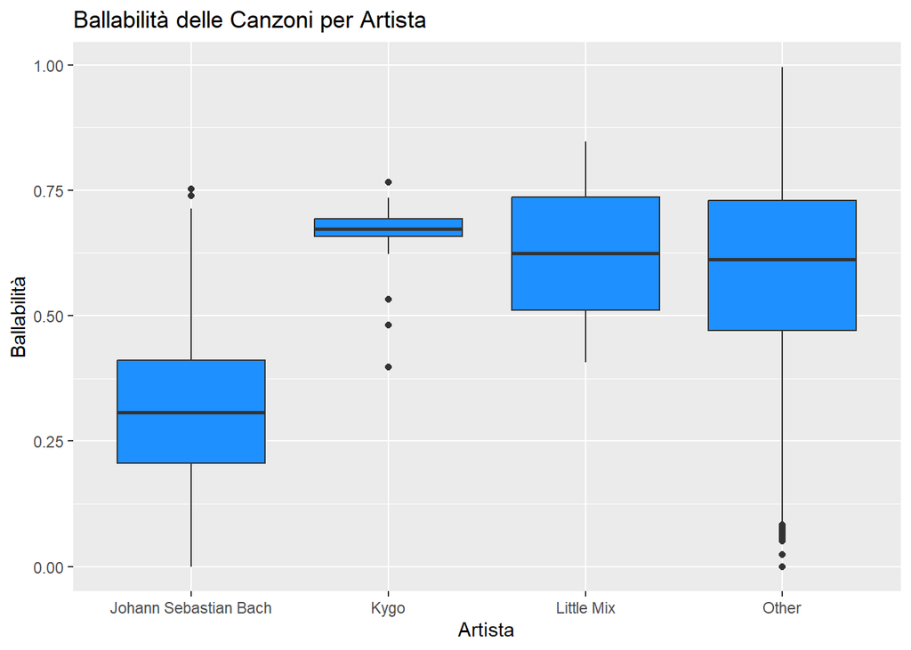

```r
# Seleziona la caratteristica 'danceability'

#install.packages("reshape2")
library(reshape2)

artists_danceability <- data.1 %>%
  select(artist_name, danceability) %>%
  melt(id = "artist_name")

# Crea un boxplot per la ballabilità
ggplot(artists_danceability, aes(x = artist_name, y = value)) +
  geom_boxplot(fill = "#1E90FF") +
  labs(x = "Artista", y = "Ballabilità", title = "Ballabilità delle Canzoni per Artista")
```